# Yifan_Wu_HW2.Rmd

# 3.7.12

## (a).

First we let

$$\frac{\sum_{i=1}^{n} x_{i}y_{i}}{\sum_{i^{'}=1}^{n} y_{i^{'}}^2} = \frac{\sum_{i=1}^{n} y_{i}x_{i}}{\sum_{i^{'}=1}^{n} x_{i^{'}}^2}$$

Because we can cancel out the numerator, that leaves us:

$$\sum_{i=1}^{n} y_{i}^2 = \sum_{i=1}^{n} x_{i}^2$$

When $\sum_{i=1}^{n} y_{i}^2 = \sum_{i=1}^{n} x_{i}^2$, the coefficient estimate for the regression of X onto Y the same as the coefficient estimate for the regression of Y onto X.

## (b).

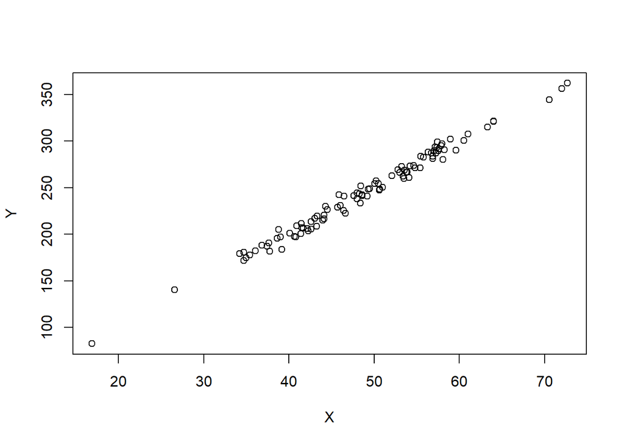

```r
true_beta_1 = 5

set.seed(0204)
x<-rnorm(100, 50, 10)
y <- true_beta_1 * x + rnorm(100,0,5)

df3 <- data.frame(X = x,Y = y)
plot(df3$X, df3$Y, xlab="X", ylab="Y")
```

```r
fit3 <- lm(Y ~ X , df3)
summary(fit3)
```

```
##
## Call:
## lm(formula = Y ~ X, data = df3)
##
## Residuals:
##      Min       1Q   Median       3Q      Max
## -12.6678  -4.0051   0.3927   3.5382  12.4882
##
## Coefficients:
##             Estimate Std. Error t value Pr(>|t|)
## (Intercept)  1.28084    2.89819   0.442     0.66
## X            4.98083    0.05819  85.601   <2e-16 ***
## ---
## Signif. codes:  0 '***' 0.001 '**' 0.01 '*' 0.05 '.' 0.1 ' ' 1
##
## Residual standard error: 5.453 on 98 degrees of freedom
## Multiple R-squared:  0.9868, Adjusted R-squared:  0.9867
## F-statistic:  7327 on 1 and 98 DF,  p-value: < 2.2e-16
```

```r
fit4 <- lm(X ~ Y , df3)
summary(fit4)
```

```
##
## Call:
## lm(formula = X ~ Y, data = df3)
##
## Residuals:
##      Min       1Q   Median       3Q      Max
## -2.51436 -0.69281 -0.07338  0.85081  2.38123
##
## Coefficients:
##             Estimate Std. Error t value Pr(>|t|)
## (Intercept) 0.391862   0.577237   0.679    0.499
## Y           0.198120   0.002314  85.601   <2e-16 ***
## ---
## Signif. codes:  0 '***' 0.001 '**' 0.01 '*' 0.05 '.' 0.1 ' ' 1
##
## Residual standard error: 1.088 on 98 degrees of freedom
## Multiple R-squared:  0.9868, Adjusted R-squared:  0.9867
## F-statistic:  7327 on 1 and 98 DF,  p-value: < 2.2e-16
```

From the above simulation, we can see that the coefficient for the regression of X on to Y(0.20) is different from the coefficient for the regression of Y onto X(4.98).

## (c).

Below is the simulated data:

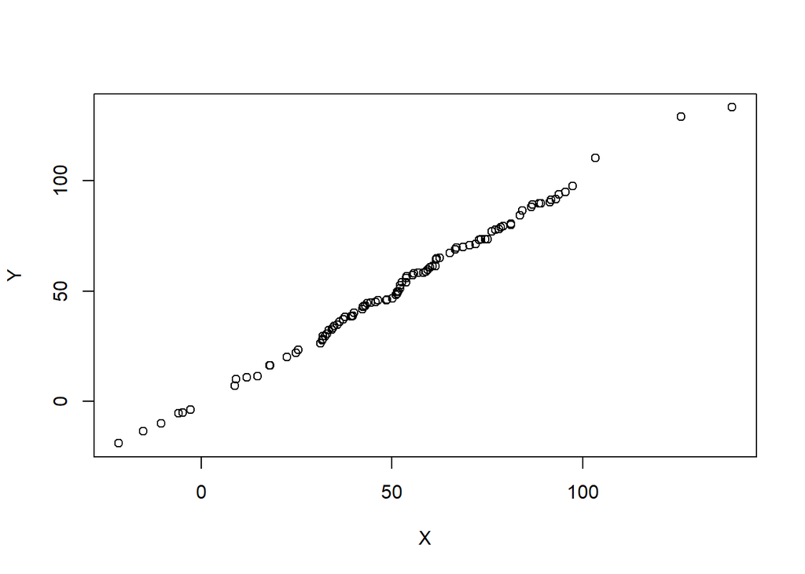

```r
true_beta_1 = 1

x<-rnorm(100, 50, 30)
y <- true_beta_1 * x + rnorm(100,0,5)

df4 <- data.frame(X = sort(x),Y = sort(y))
plot(df4$X, df4$Y, xlab="X", ylab="Y")
```

```r
fit5 <- lm(Y ~ X , df4)
summary(fit5)
```

```
##
## Call:
## lm(formula = Y ~ X, data = df4)
##
## Residuals:
##     Min      1Q  Median      3Q     Max
## -7.0255 -0.9896  0.0242  0.9713  6.3409
##
## Coefficients:
##             Estimate Std. Error t value Pr(>|t|)
## (Intercept) -1.06370    0.39319  -2.705  0.00805 **
## X            1.01579    0.00657 154.608  < 2e-16 ***
## ---
## Signif. codes:  0 '***' 0.001 '**' 0.01 '*' 0.05 '.' 0.1 ' ' 1
##
## Residual standard error: 1.903 on 98 degrees of freedom
## Multiple R-squared:  0.9959, Adjusted R-squared:  0.9959
## F-statistic: 2.39e+04 on 1 and 98 DF,  p-value: < 2.2e-16
```

```r
fit6 <- lm(X ~ Y , df3)
summary(fit6)
```

```
##
## Call:
## lm(formula = X ~ Y, data = df3)
##
## Residuals:
##      Min       1Q   Median       3Q      Max
## -2.51436 -0.69281 -0.07338  0.85081  2.38123
##
## Coefficients:
##             Estimate Std. Error t value Pr(>|t|)
## (Intercept) 0.391862   0.577237   0.679    0.499
## Y           0.198120   0.002314  85.601   <2e-16 ***
## ---
## Signif. codes:  0 '***' 0.001 '**' 0.01 '*' 0.05 '.' 0.1 ' ' 1
##
## Residual standard error: 1.088 on 98 degrees of freedom
## Multiple R-squared:  0.9868, Adjusted R-squared:  0.9867
## F-statistic:  7327 on 1 and 98 DF,  p-value: < 2.2e-16
```

# 3.7.13

## (a).

```r
set.seed(1002)
x <- rnorm(100, 0, 1)
```

## (b).

```r
set.seed(1003)
eps <- rnorm(100, 0, 0.25)
```

## (c).

```r
true_beta_0 = -1
true_beta_1 = 0.5

y <- true_beta_1 * x + true_beta_0 + eps
length(y)
```

```
## [1] 100
```

The length of vector y is 100. $\beta_0 = -1$ and $\beta_1 = 0.5$.

## (d).

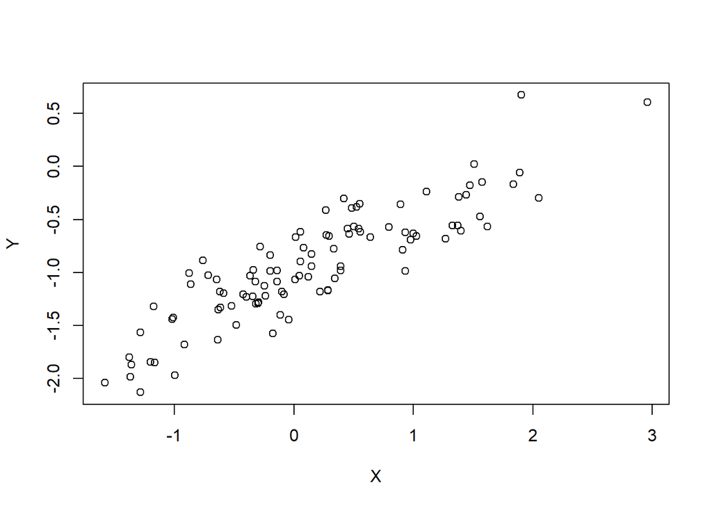

```r
df5 <- data.frame(X = x,Y = y)
plot(df5$X, df5$Y, xlab="X", ylab="Y")
```

We can see from the scatter plot that there is a clear positive linear relationship between x and y.

## (e).

```r
fit8 <- lm(Y ~ X , df5)
summary(fit8)
```

```
##
## Call:
## lm(formula = Y ~ X, data = df5)
##
## Residuals:
##      Min       1Q   Median       3Q      Max
## -0.47645 -0.18557 -0.00735  0.16839  0.71031
##
## Coefficients:
##             Estimate Std. Error t value Pr(>|t|)
## (Intercept) -1.00848    0.02548  -39.58   <2e-16 ***
## X            0.51070    0.02763   18.48   <2e-16 ***
## ---
## Signif. codes:  0 '***' 0.001 '**' 0.01 '*' 0.05 '.' 0.1 ' ' 1
##
## Residual standard error: 0.2513 on 98 degrees of freedom
## Multiple R-squared:  0.7771, Adjusted R-squared:  0.7748
## F-statistic: 341.6 on 1 and 98 DF,  p-value: < 2.2e-16
```

We can see that the model is a good fit because the p-value for the whole model is smaller than 0.05 and so is the p-value of coefficient of x and the intercept.

True $\beta_{0} = -1$, fitted $\beta_{0} = -1.01$;

True $\beta_{1} = 0.5$, fitted $\beta_{1} = 0.51$.

The fitted coefficients are both very close to the truth.

## (f).

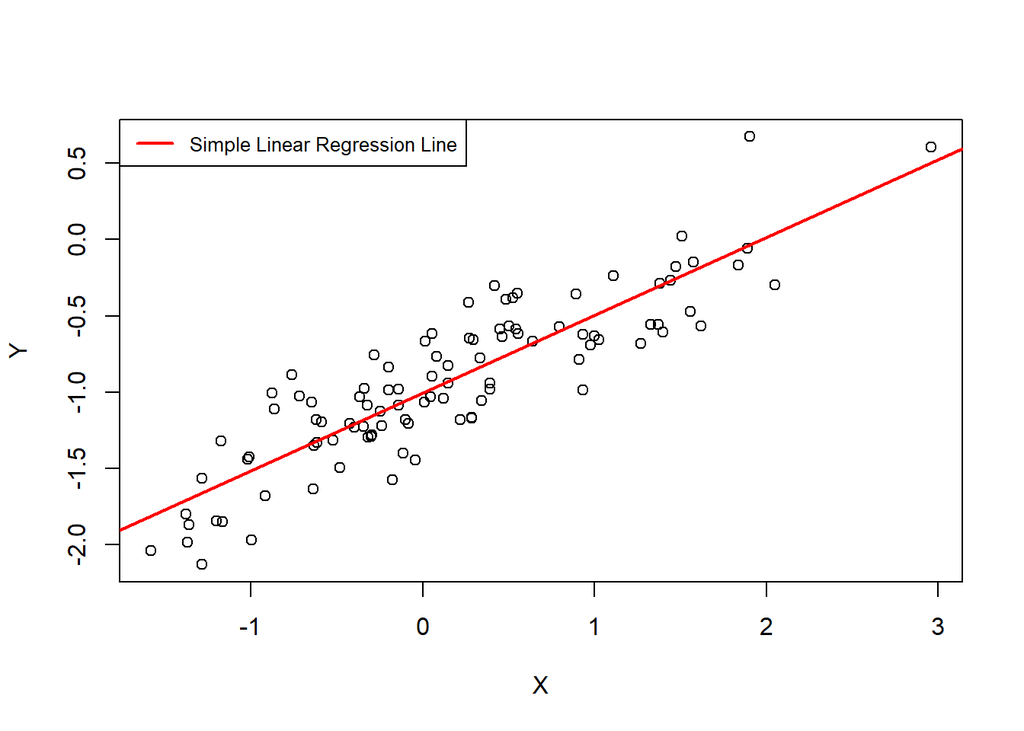

```r
plot(df5$X, df5$Y, xlab="X", ylab="Y")
abline(fit8, col="red",lwd=2) # regression line (y~x)
legend("topleft", legend = "Simple Linear Regression Line", col="red",lty=1:2, cex=0.8,lwd=2)
```

## (g).

```r
fit9 <- lm(Y ~ X + I(X^2) , df5)
summary(fit9)
```

```
##
## Call:
## lm(formula = Y ~ X + I(X^2), data = df5)
##
## Residuals:
##      Min       1Q   Median       3Q      Max
## -0.49210 -0.18430 -0.00648  0.16299  0.75210
##
## Coefficients:
##             Estimate Std. Error t value Pr(>|t|)
## (Intercept) -0.98888    0.03089 -32.015   <2e-16 ***
## X            0.52851    0.03185  16.592   <2e-16 ***
## I(X^2)      -0.02626    0.02346  -1.119    0.266
## ---
## Signif. codes:  0 '***' 0.001 '**' 0.01 '*' 0.05 '.' 0.1 ' ' 1
##
## Residual standard error: 0.2509 on 97 degrees of freedom
## Multiple R-squared:  0.7799, Adjusted R-squared:  0.7754
## F-statistic: 171.9 on 2 and 97 DF,  p-value: < 2.2e-16
```

## (h).

```r
set.seed(1005)
x <- rnorm(100, 0, 1)
eps2 <- rnorm(100, 0, 0.05)

true_beta_0 = -1
true_beta_1 = 0.5

y <- true_beta_1 * x + true_beta_0 + eps2
length(y)
```

```
## [1] 100
```

```r
df6 <- data.frame(X = x,Y = y)
plot(df6$X, df6$Y, xlab="X", ylab="Y")

fit10 <- lm(Y ~ X , df6)
summary(fit10)
```

```
##
## Call:
## lm(formula = Y ~ X, data = df6)
##
## Residuals:
##       Min        1Q    Median        3Q       Max
## -0.152393 -0.036770 -0.002437  0.035297  0.159363
##
## Coefficients:
##              Estimate Std. Error t value Pr(>|t|)
## (Intercept) -0.991931   0.005417  -183.1   <2e-16 ***
## X            0.499709   0.004647   107.5   <2e-16 ***
## ---
## Signif. codes:  0 '***' 0.001 '**' 0.01 '*' 0.05 '.' 0.1 ' ' 1
##
## Residual standard error: 0.05413 on 98 degrees of freedom
## Multiple R-squared:  0.9916, Adjusted R-squared:  0.9915
## F-statistic: 1.156e+04 on 1 and 98 DF,  p-value: < 2.2e-16
```

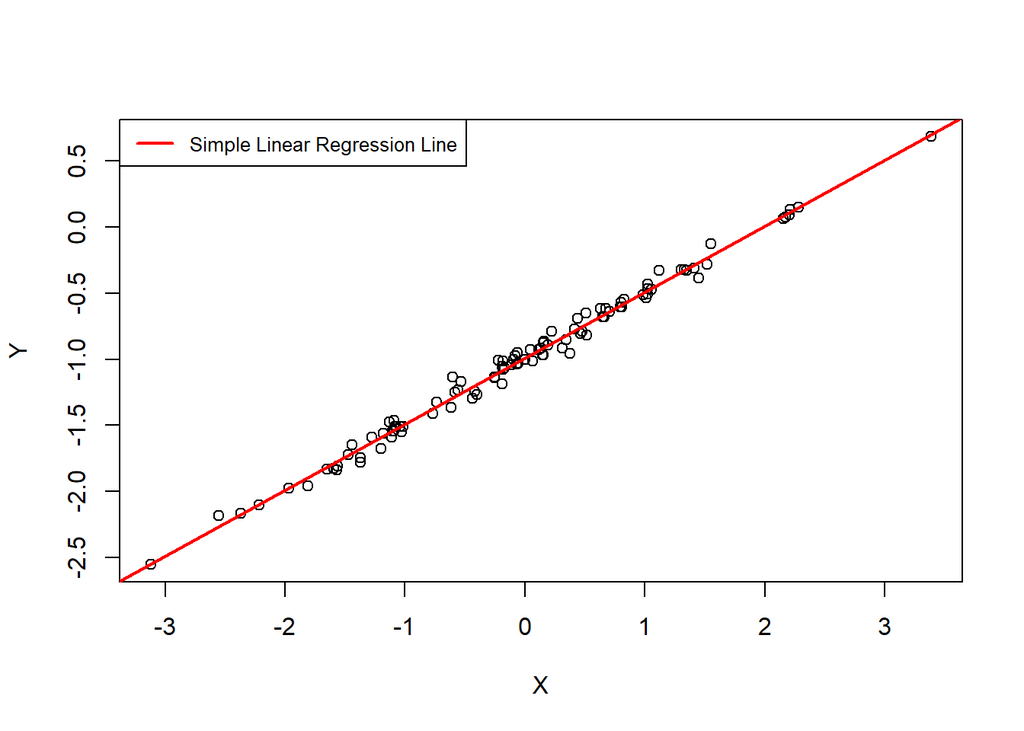

```r
#plot(df6$X, df6$Y, xlab="X", ylab="Y")
abline(fit10, col="red",lwd=2) # regression line (y~x)
legend("topleft", legend = "Simple Linear Regression Line", col="red",lty=1:2, cex=0.8,lwd=2)
```

```r
fit11 <- lm(Y ~ X + I(X^2) , df6)
summary(fit11)
```

```
##
## Call:
## lm(formula = Y ~ X + I(X^2), data = df6)
##
## Residuals:
##       Min        1Q    Median        3Q       Max
## -0.153761 -0.036311 -0.000862  0.034157  0.158235
##
## Coefficients:
##              Estimate Std. Error  t value Pr(>|t|)
## (Intercept) -0.990400   0.006612 -149.795   <2e-16 ***
## X            0.499702   0.004667  107.064   <2e-16 ***
## I(X^2)      -0.001128   0.002765   -0.408    0.684
## ---
## Signif. codes:  0 '***' 0.001 '**' 0.01 '*' 0.05 '.' 0.1 ' ' 1
##
## Residual standard error: 0.05436 on 97 degrees of freedom
## Multiple R-squared:  0.9916, Adjusted R-squared:  0.9914
## F-statistic:  5732 on 2 and 97 DF,  p-value: < 2.2e-16
```

We can see that if we decrease the noise level, the data point will be less scattered and the linear trend becomes more obvious. The estimated $\beta_{0} = -0.99$ and $\beta_{1} = 0.50$ they are both very close to the truth and even closer compare to the original more noisy simulation. When we try to fit the data using a quadratic model, the $X^2$ term is not significant because the p-value is too big.

## (i).

```r
set.seed(1005)
x <- rnorm(100, 0, 1)
eps3 <- rnorm(100, 0, 0.8)

true_beta_0 = -1
true_beta_1 = 0.5

y <- true_beta_1 * x + true_beta_0 + eps3
length(y)
```

```
## [1] 100
```

```r
df7 <- data.frame(X = x,Y = y)
plot(df7$X, df7$Y, xlab="X", ylab="Y")

fit12 <- lm(Y ~ X , df7)
summary(fit12)
```

```
##
## Call:
## lm(formula = Y ~ X, data = df7)
##
## Residuals:
##     Min      1Q  Median      3Q     Max
## -2.4383 -0.5883 -0.0390  0.5648  2.5498
##
## Coefficients:
##             Estimate Std. Error t value Pr(>|t|)
## (Intercept) -0.87090    0.08668 -10.048  < 2e-16 ***
## X            0.49535    0.07436   6.662 1.59e-09 ***
## ---
## Signif. codes:  0 '***' 0.001 '**' 0.01 '*' 0.05 '.' 0.1 ' ' 1
##
## Residual standard error: 0.866 on 98 degrees of freedom
## Multiple R-squared:  0.3117, Adjusted R-squared:  0.3047
## F-statistic: 44.38 on 1 and 98 DF,  p-value: 1.587e-09
```

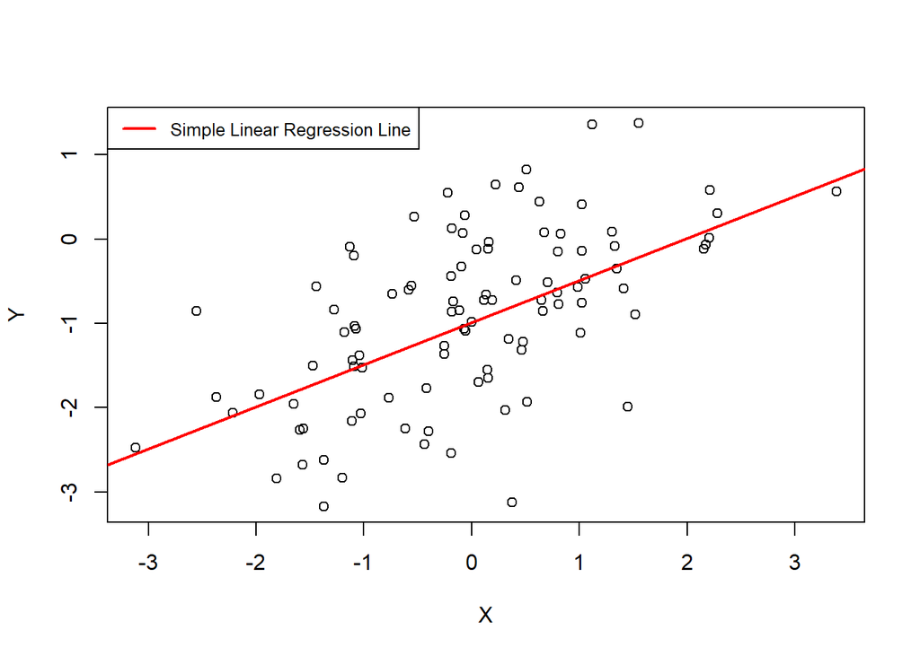

```r
#plot(df7$X, df7$Y, xlab="X", ylab="Y")
abline(fit10, col="red",lwd=2) # regression line (y~x)
legend("topleft", legend = "Simple Linear Regression Line", col="red",lty=1:2, cex=0.8,lwd=2)
```

```r
fit13 <- lm(Y ~ X + I(X^2) , df7)
summary(fit13)
```

```
##
## Call:
## lm(formula = Y ~ X + I(X^2), data = df7)
##
## Residuals:
##     Min      1Q  Median      3Q     Max
## -2.4602 -0.5810 -0.0138  0.5465  2.5318
##
## Coefficients:
##             Estimate Std. Error t value Pr(>|t|)
## (Intercept) -0.84639    0.10579  -8.001 2.67e-12 ***
## X            0.49523    0.07468   6.632 1.89e-09 ***
## I(X^2)      -0.01804    0.04425  -0.408    0.684
## ---
## Signif. codes:  0 '***' 0.001 '**' 0.01 '*' 0.05 '.' 0.1 ' ' 1
##
## Residual standard error: 0.8697 on 97 degrees of freedom
## Multiple R-squared:  0.3129, Adjusted R-squared:  0.2987
## F-statistic: 22.08 on 2 and 97 DF,  p-value: 1.249e-08
```

We can see that if we increase the noise level, the data point will be more scattered and the linear trend becomes less obvious. The estimated $\beta_{0} = -0.87$ and $\beta_{1} = 0.50$ they are both very close to the truth but deviate more from the truth compare to the original less noisy simulation. When we try to fit the data using a quadratic model, the $X^2$ term is not significant because the p-value is too big. When increase the noisy level, although the p-value is still smaller than 0.05, the p-value is bigger than the previous less noisy one.

## (j).

```r
round(confint(fit8, '(Intercept)', level=0.95),2)
```

```
##             2.5 % 97.5 %
## (Intercept) -1.06  -0.96
```

```r
round(confint(fit8, 'X', level=0.95),2)
```

```
##   2.5 % 97.5 %
## X  0.46   0.57
```

CI for original data set:

$\beta_{0} = [-1.06 , -0.96]$

$\beta_{1} = [0.46, 0.57]$

```r
round(confint(fit10, '(Intercept)', level=0.95),2)
```

```
##             2.5 % 97.5 %
## (Intercept)    -1  -0.98
```

```r
round(confint(fit10, 'X', level=0.95),2)
```

```
##   2.5 % 97.5 %
## X  0.49   0.51
```

CI for less noisy data set:

$\beta_{0} = [-1, -0.98]$

$\beta_{1} = [ 0.49 , 0.51]$

```r
round(confint(fit12, '(Intercept)', level=0.95),2)
```

```
##             2.5 % 97.5 %
## (Intercept) -1.04   -0.7
```

```r
round(confint(fit12, 'X', level=0.95),2)
```

```
##   2.5 % 97.5 %
## X  0.35   0.64
```

CI for more noisy data set:

$\beta_{0} = [-1.04 , -0.7]$

$\beta_{1} = [ 0.35 , 0.64]$

From the CI for $\beta_{0}$ and $\beta_{1}$ we can conclude that the more noisy the data is, the wider the CIs for their coefficients are.

# 3.7.15

## (a).

We find out the p-value for the regression model for all predictors with “Crime” and find out the ones that exceeds 0.05:

```r
library(MASS)
library(reshape2)
library(dplyr)
library(broom)
library(reshape)
df_b = Boston
melt_boston <- melt((df_b), id.vars = "crim")

lr_bostn=melt_boston %>% group_by(variable) %>% do(tidy(lm(crim ~ value, data=.)))
lr_bostn
```

```
## # A tibble: 26 x 6
## # Groups:   variable [13]
##    variable term        estimate std.error statistic               p.value
##    <fct>    <chr>          <dbl>     <dbl>     <dbl>                 <dbl>
##  1 zn       (Intercept)   4.45      0.417      10.7               4.04e-24
##  2 zn       value       - 0.0739    0.0161    - 4.59              5.51e- 6
##  3 indus    (Intercept) - 2.06      0.667     - 3.09              2.09e- 3
##  4 indus    value         0.510     0.0510      9.99              1.45e-21
##  5 chas     (Intercept)   3.74      0.396       9.45              1.24e-19
##  6 chas     value       - 1.89      1.51      - 1.26              2.09e- 1
##  7 nox      (Intercept) -13.7       1.70      - 8.07              5.08e-15
##  8 nox      value        31.2       3.00       10.4               3.75e-23
##  9 rm       (Intercept)  20.5       3.36        6.09              2.27e- 9
## 10 rm       value       - 2.68      0.532     - 5.04              6.35e- 7
## # ... with 16 more rows
```

```r
lr_boston_not_sig = subset(lr_bostn, lr_bostn$p.value > 0.05)
lr_boston_not_sig
```

```
## # A tibble: 1 x 6
## # Groups:   variable [1]
##   variable term  estimate std.error statistic p.value
##   <fct>    <chr>    <dbl>     <dbl>     <dbl>   <dbl>
## 1 chas     value    -1.89      1.51     -1.26   0.209
```

We can see from the above result that, except for the predictor “chas”, every other variables in the data frame “Boston” has statistically significant association the response.

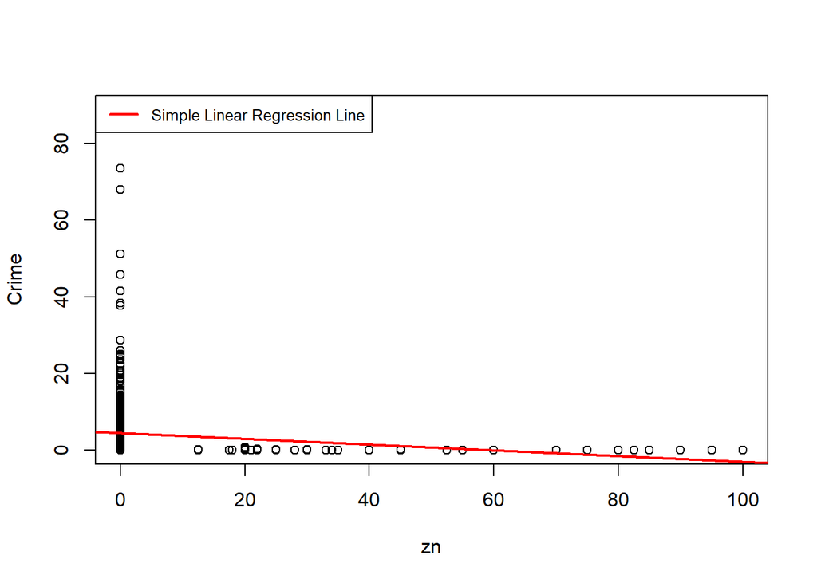

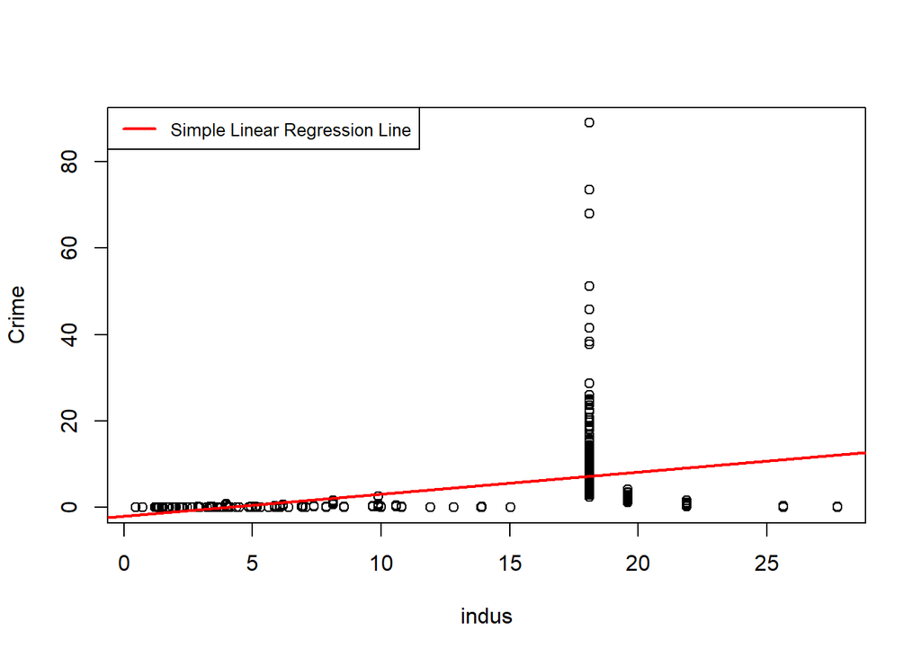

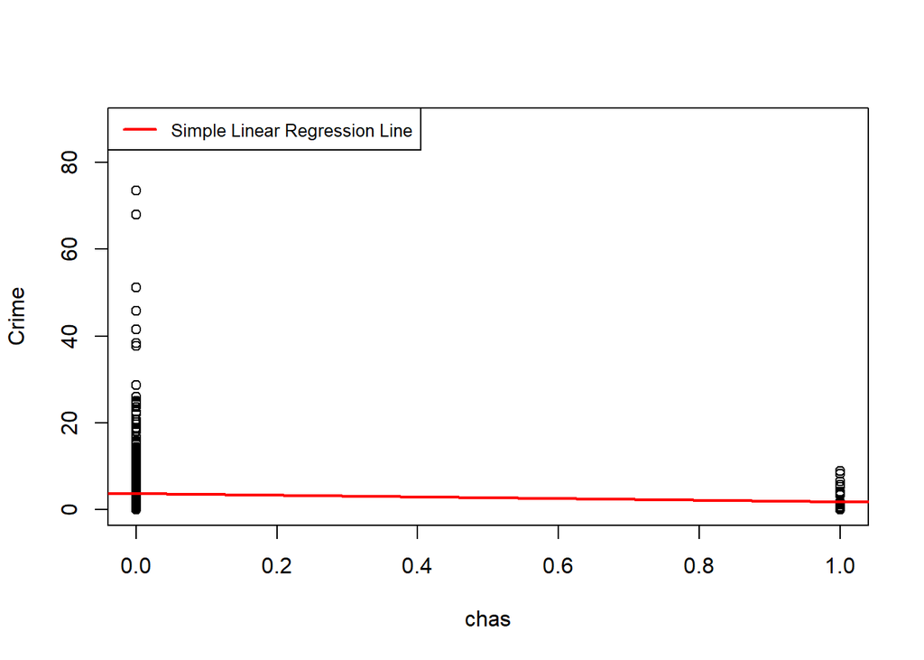

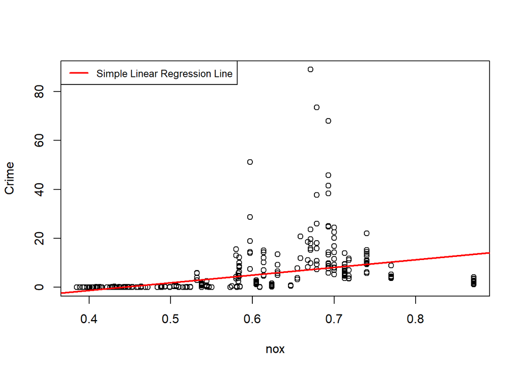

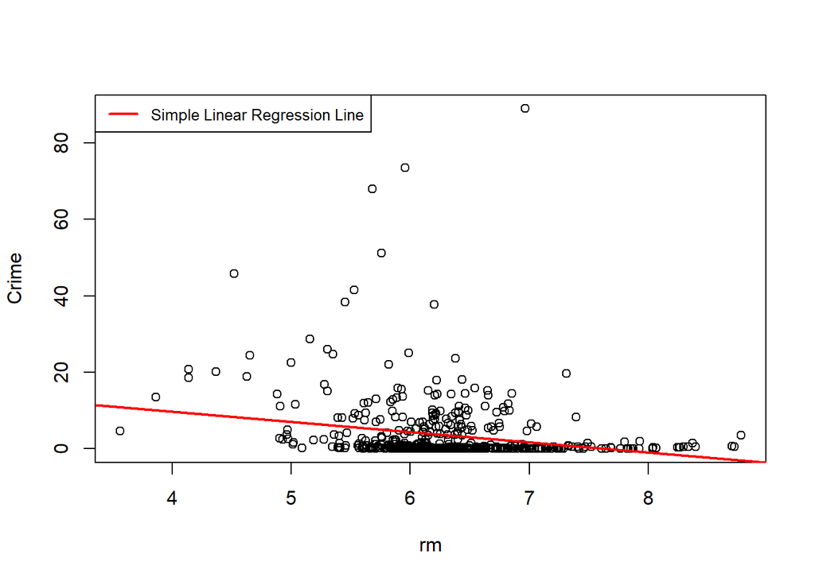

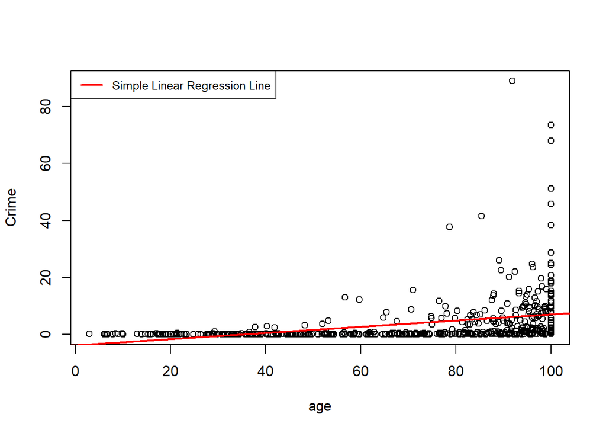

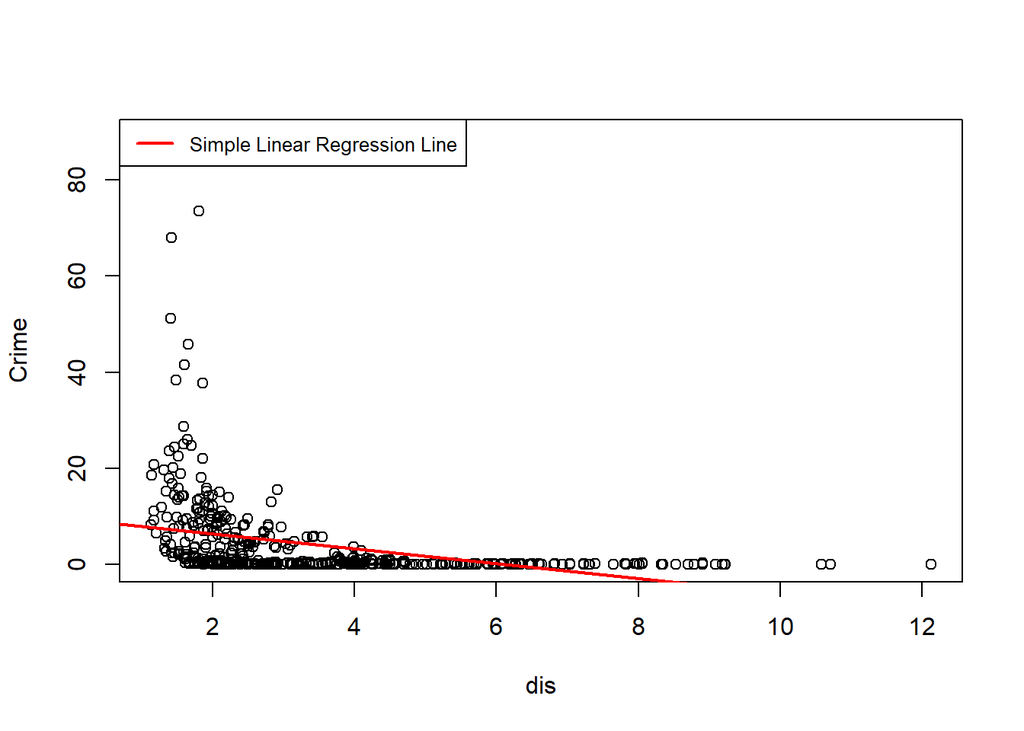

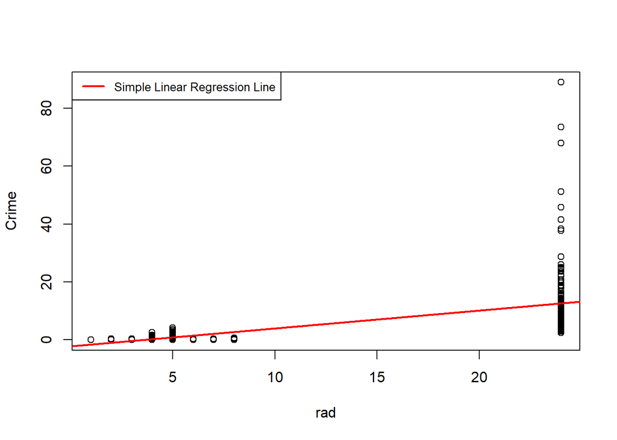

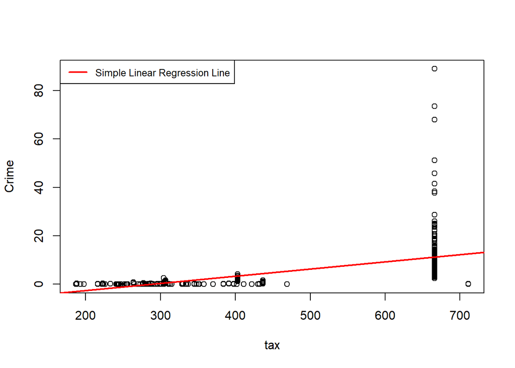

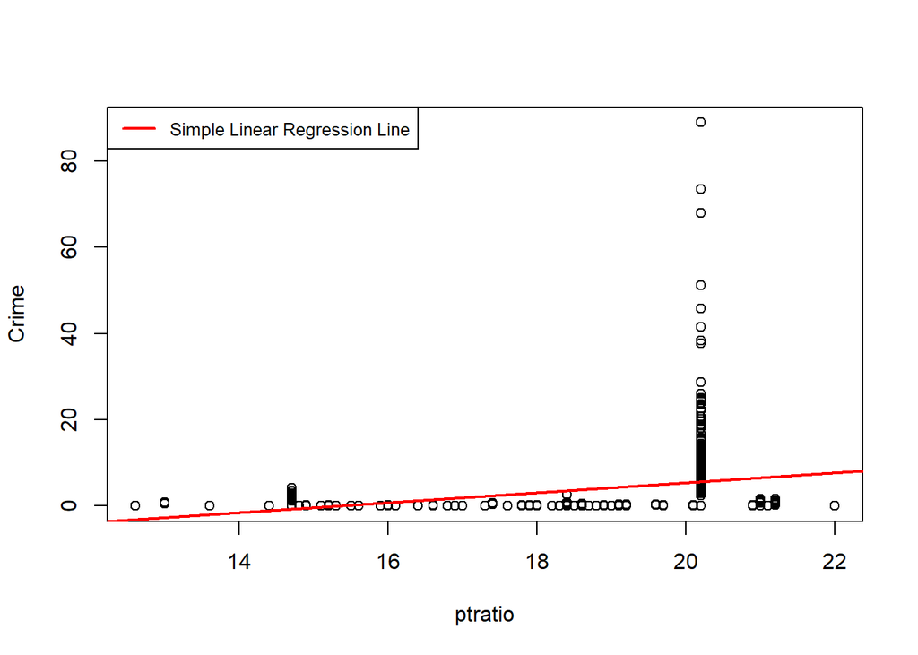

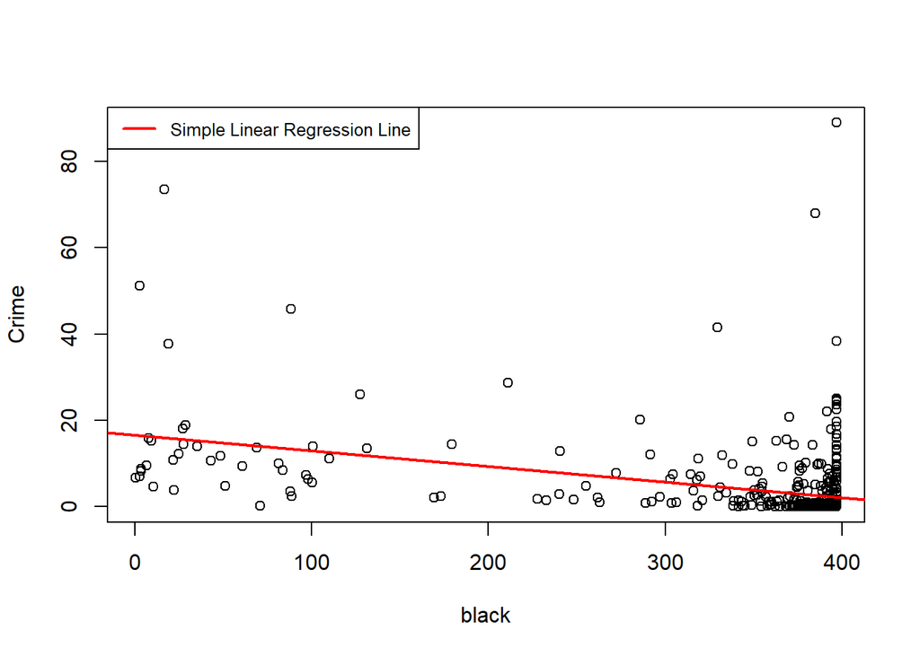

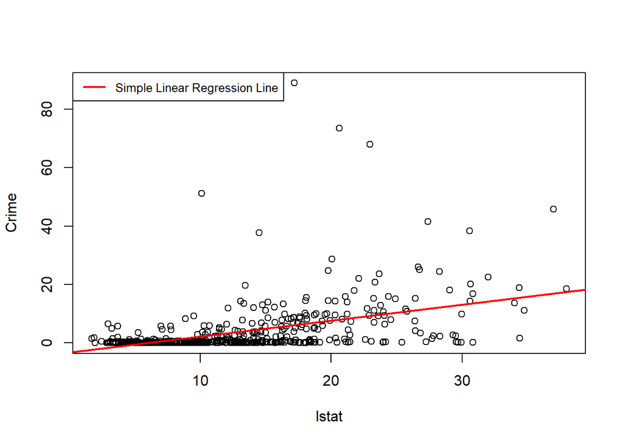

[1 more figures not shown]

```r
for(i in names(Boston[-1])){
  plot( Boston[[i]], Boston$crim, xlab=i, ylab="Crime")
  abline(lm(Boston$crim ~  Boston[[i]], data = Boston), col="red",lwd=2) # regression line (y~x)
  legend("topleft", legend = "Simple Linear Regression Line", col="red",lty=1:2, cex=0.8,lwd=2)
 }
```

## (b).

```r
mul_lr_boston <- lm(crim~.,Boston)
summary(mul_lr_boston)
```

```
##
## Call:
## lm(formula = crim ~ ., data = Boston)
##
## Residuals:
##    Min     1Q Median     3Q    Max
## -9.924 -2.120 -0.353  1.019 75.051
##
## Coefficients:
##               Estimate Std. Error t value Pr(>|t|)
## (Intercept)  17.033228   7.234903   2.354 0.018949 *
## zn            0.044855   0.018734   2.394 0.017025 *
## indus        -0.063855   0.083407  -0.766 0.444294
## chas         -0.749134   1.180147  -0.635 0.525867
## nox         -10.313535   5.275536  -1.955 0.051152 .
## rm            0.430131   0.612830   0.702 0.483089
## age           0.001452   0.017925   0.081 0.935488
## dis          -0.987176   0.281817  -3.503 0.000502 ***
## rad           0.588209   0.088049   6.680 6.46e-11 ***
## tax          -0.003780   0.005156  -0.733 0.463793
## ptratio      -0.271081   0.186450  -1.454 0.146611
## black        -0.007538   0.003673  -2.052 0.040702 *
## lstat         0.126211   0.075725   1.667 0.096208 .
## medv         -0.198887   0.060516  -3.287 0.001087 **
## ---
## Signif. codes:  0 '***' 0.001 '**' 0.01 '*' 0.05 '.' 0.1 ' ' 1
##
## Residual standard error: 6.439 on 492 degrees of freedom
## Multiple R-squared:  0.454,  Adjusted R-squared:  0.4396
## F-statistic: 31.47 on 13 and 492 DF,  p-value: < 2.2e-16
```

Unlike the result from the seperate simple linear regressoin, only a few variables is significant when we are fitting the data using multiple linear regression. The significant variables are: “zn”, “dis”, “rad”, “black”, and “medv”. So for the above predictors, we can reject the null hypothesis $H_{0}:\ \beta_{j} = 0$.

## (c).

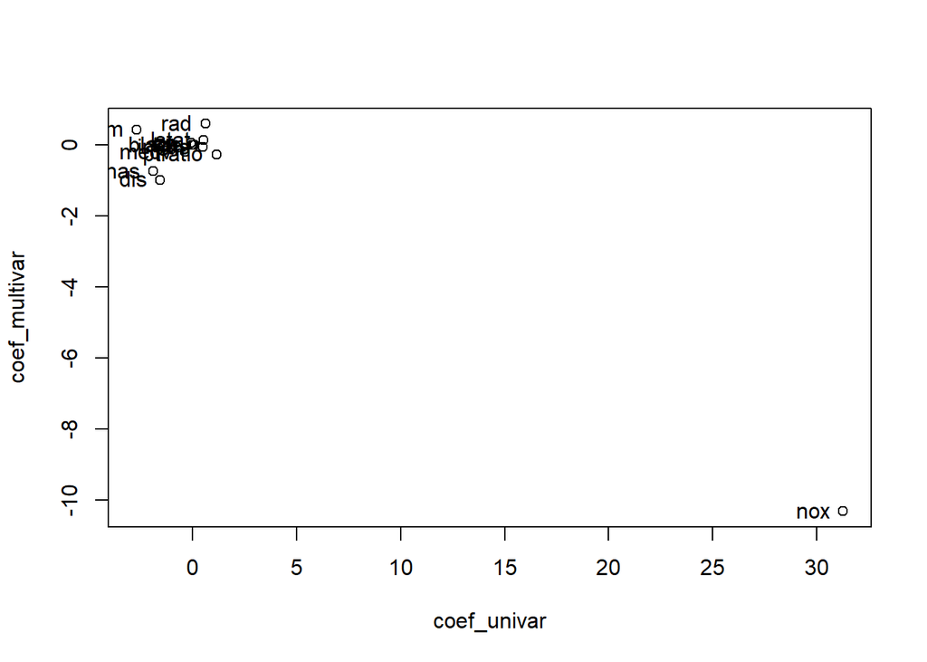

```r
coef_univar = lr_bostn$estimate[lr_bostn$term != "(Intercept)"]
coef_multivar = mul_lr_boston$coefficients[-1]
coef = data.frame(coef_univar, coef_multivar)

plot(coef_univar, coef_multivar)
with(coef, text(coef_multivar~coef_univar, labels = names(Boston[-1]), pos = 2))
```

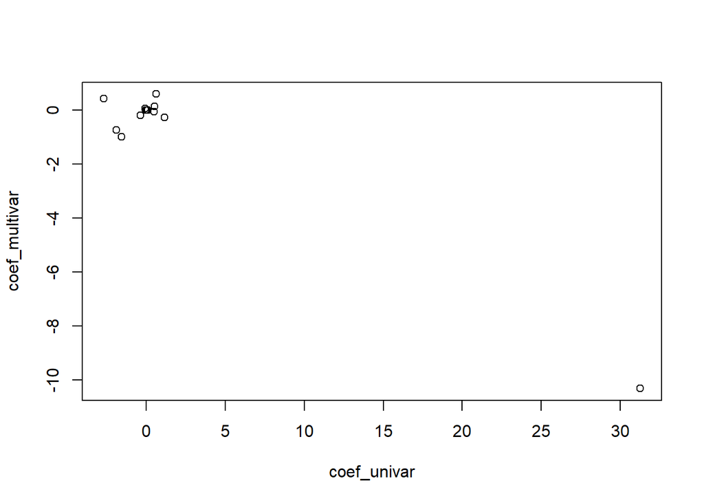

```r
plot(coef_univar, coef_multivar)
```

From the above result we can see that most of the coefficients lies around 0 with small difference within each predictor except for “nox”, which apprears to be an outlier whose coefficients varies greatly. Next we investigate “Nox” on its own to find out what’s happening:

```r
#Univeriate linear regression for nox:
summary(lm(Boston$crim ~ Boston$nox, Boston))
```

```
##
## Call:
## lm(formula = Boston$crim ~ Boston$nox, data = Boston)
##
## Residuals:
##     Min      1Q  Median      3Q     Max
## -12.371  -2.738  -0.974   0.559  81.728
##
## Coefficients:
##             Estimate Std. Error t value Pr(>|t|)
## (Intercept)  -13.720      1.699  -8.073 5.08e-15 ***
## Boston$nox    31.249      2.999  10.419  < 2e-16 ***
## ---
## Signif. codes:  0 '***' 0.001 '**' 0.01 '*' 0.05 '.' 0.1 ' ' 1
##
## Residual standard error: 7.81 on 504 degrees of freedom
## Multiple R-squared:  0.1772, Adjusted R-squared:  0.1756
## F-statistic: 108.6 on 1 and 504 DF,  p-value: < 2.2e-16
```

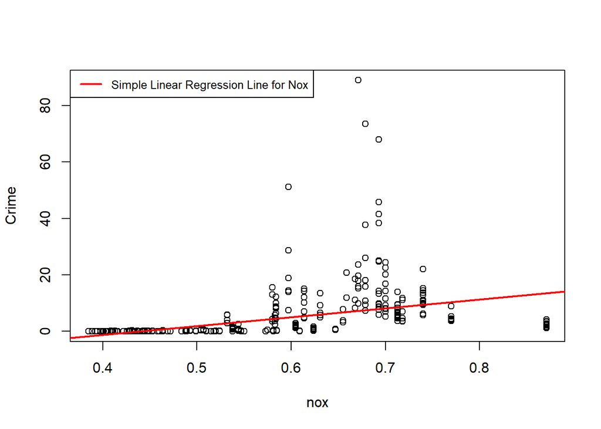

```r
plot( Boston$nox, Boston$crim, xlab="nox", ylab="Crime")
abline(lm(Boston$crim ~ Boston$nox, Boston), col="red",lwd=2) # regression line (y~x)
legend("topleft", legend = "Simple Linear Regression Line for Nox", col="red",lty=1:2, cex=0.8,lwd=2)
```

```r
#Multivariate linear regressoin:
summary(mul_lr_boston)
```

```
##
## Call:
## lm(formula = crim ~ ., data = Boston)
##
## Residuals:
##    Min     1Q Median     3Q    Max
## -9.924 -2.120 -0.353  1.019 75.051
##
## Coefficients:
##               Estimate Std. Error t value Pr(>|t|)
## (Intercept)  17.033228   7.234903   2.354 0.018949 *
## zn            0.044855   0.018734   2.394 0.017025 *
## indus        -0.063855   0.083407  -0.766 0.444294
## chas         -0.749134   1.180147  -0.635 0.525867
## nox         -10.313535   5.275536  -1.955 0.051152 .
## rm            0.430131   0.612830   0.702 0.483089
## age           0.001452   0.017925   0.081 0.935488
## dis          -0.987176   0.281817  -3.503 0.000502 ***
## rad           0.588209   0.088049   6.680 6.46e-11 ***
## tax          -0.003780   0.005156  -0.733 0.463793
## ptratio      -0.271081   0.186450  -1.454 0.146611
## black        -0.007538   0.003673  -2.052 0.040702 *
## lstat         0.126211   0.075725   1.667 0.096208 .
## medv         -0.198887   0.060516  -3.287 0.001087 **
## ---
## Signif. codes:  0 '***' 0.001 '**' 0.01 '*' 0.05 '.' 0.1 ' ' 1
##
## Residual standard error: 6.439 on 492 degrees of freedom
## Multiple R-squared:  0.454,  Adjusted R-squared:  0.4396
## F-statistic: 31.47 on 13 and 492 DF,  p-value: < 2.2e-16
```

For univeriate linear regresson: the coefficient for nox(31.25) is very significant(2e-16).

This suggestes that when we are taking all variables into account: while holding all other variables constant, “crim” and “nox” is negatively correlated with each other. Holding all other variables constant, increase in one unit in “nox” will cause decrease in “crim” for 10 units. The inconsistant result between univariate regression and multivariate regresion means that “nox” is interacting with other variables in the data.